# Projek TSA

# Packages

```r
library(ggplot2)
library(tsibble)
library(tseries)
library(MASS)
library(forecast)
library(TSA)
library(TTR)
library(aTSA)
library(graphics)
```

# Input Data

```r
data1 <- read.csv("Data - Sheet5.csv")
colnames(data1) <- c("TMA_Manggarai", "CH.Bogor", "CH.Depok", "CH.Manggarai")
TMA = data1[,1] # Tinggi muka air di Pintu Air Manggarai
CHM = data1[,4] # Curah hujan Manggarai
CHD = data1[,3] # Curah hujan Depok
CHB = data1[,2] # Curah hujan Bogor

# Bentuk Time Series
TMA.ts = ts(TMA)
CHM.ts = ts(CHM)
CHD.ts = ts(CHD)
CHB.ts = ts(CHB)
data.ts = ts(data1)

str(data1)
```

```
## 'data.frame':    10176 obs. of  4 variables:
##  $ TMA_Manggarai: int  595 595 595 595 595 595 595 595 595 595 ...
##  $ CH.Bogor     : num  0 0 0 0 0 0 0 0.2 0.2 0.1 ...
##  $ CH.Depok     : num  0 0 0 0 0 0 0.1 1 0.1 0 ...
##  $ CH.Manggarai : num  0 0 0 0 0 0 0 0.2 0.2 0.1 ...
```

# Missing Value

## Cek Missing Value

```r
library(dplyr)
# Menghitung jumlah data kosong dalam setiap kolom dataframe df
kosong_per_kolom <- data1 %>%
  summarise_all(~ sum(is.na(.)))

# Tampilkan hasilnya
print(kosong_per_kolom)
```

```
##   TMA_Manggarai CH.Bogor CH.Depok CH.Manggarai
## 1             2        0        0            0
```

Terdapat dua missing value pada kolom TMA Pintu Air Manggarai. Untuk menangani hal tersebut, kita gunakan imputasi dengan interpolasi.

## Imputasi

```r
library(imputeTS)
```

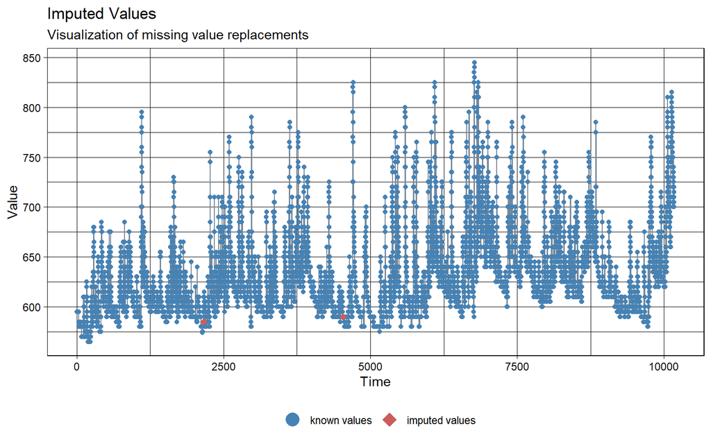

```r
data1$TMA2 <- na_interpolation(TMA)
ggplot_na_imputations(data1$TMA_Manggarai, data1$TMA2)
```

```r
TMA2 = data1$TMA2
TMA2.ts = ts(TMA2)
```

# Eksplorasi Data

## Plot Data Penuh

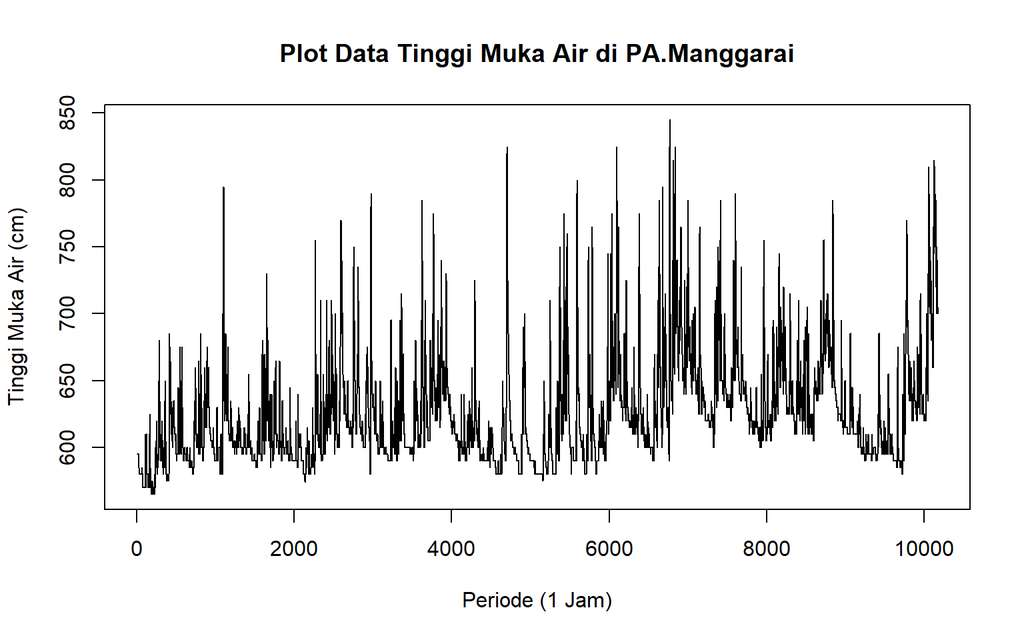

```r
plot.ts(TMA2.ts, lty=1, xlab="Periode (1 Jam)", ylab="Tinggi Muka Air (cm)", main="Plot Data Tinggi Muka Air di PA.Manggarai")
```

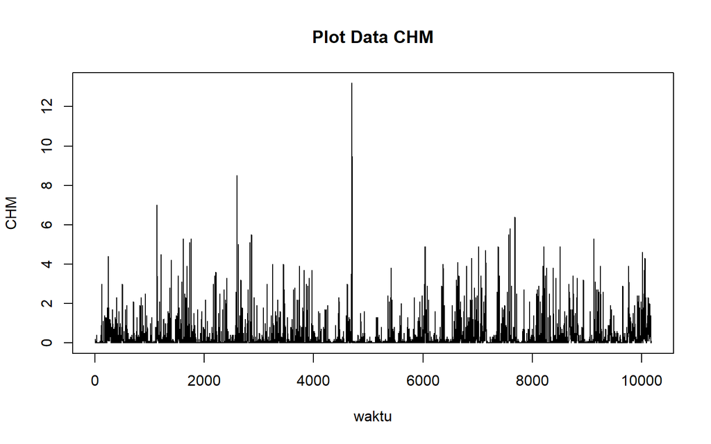

```r
plot.ts(CHM.ts, lty=1, xlab="waktu", ylab="CHM", main="Plot Data CHM")
```

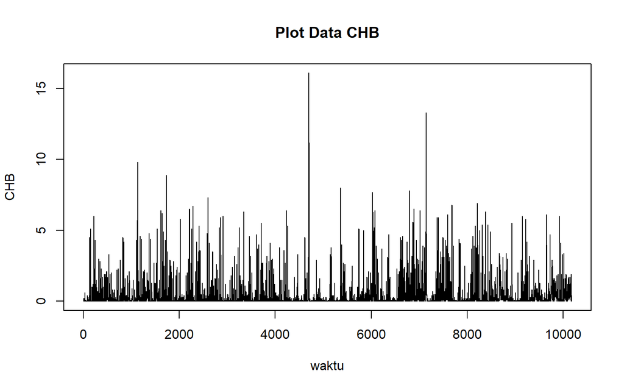

```r
plot.ts(CHB.ts, lty=1, xlab="waktu", ylab="CHB", main="Plot Data CHB")
```

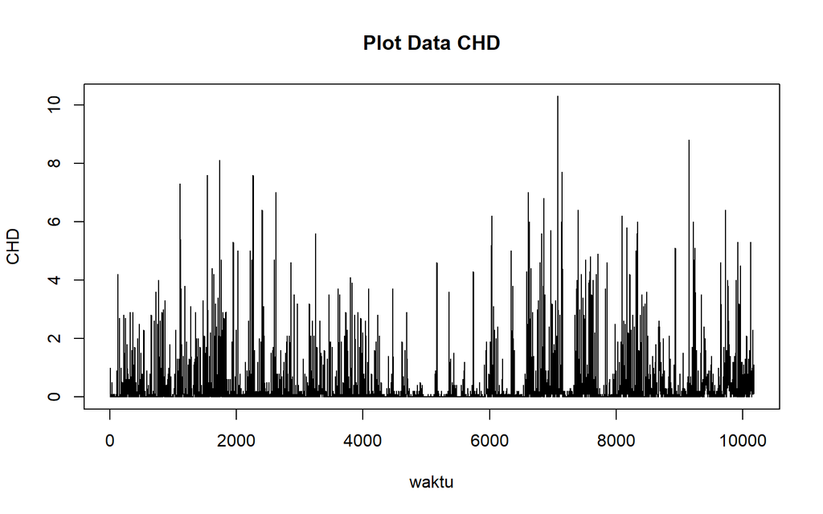

```r
plot.ts(CHD.ts, lty=1, xlab="waktu", ylab="CHD", main="Plot Data CHD")
```

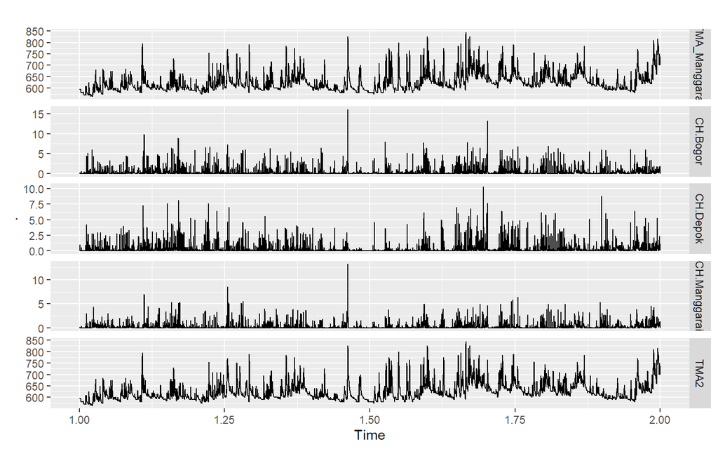

```r
ts(data1, freq = nrow(data1)) %>%
  autoplot(facets = TRUE)
```

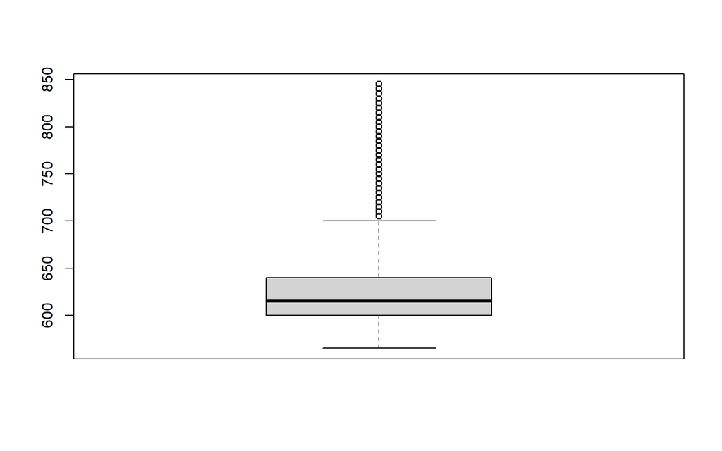

```r
boxplot(TMA2.ts)
```

Plot data tinggi muka air di Pintu Air Manggarai cenderung naik turun pada periode tertentu (seasonal)

# ARIMA

## Eksplorasi Data

### Plot Data Latih

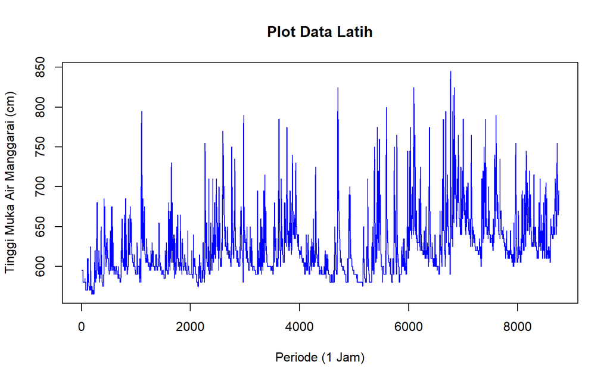

```r
TMA.train<-TMA2[1:8754]
train.ts<-ts(TMA.train)
plot.ts(train.ts, lty=1, xlab="Periode (1 Jam)", ylab="Tinggi Muka Air Manggarai (cm)", main="Plot Data Latih", col="blue")
```

Berdasarkan plot data deret waktu pada data latih, terlihat bahwa data cenderung memiliki trend yang naik dan turun. Hal ini mengindikasikan bahwa data tidak stasioner dalam rataan.

### Plot Data Uji

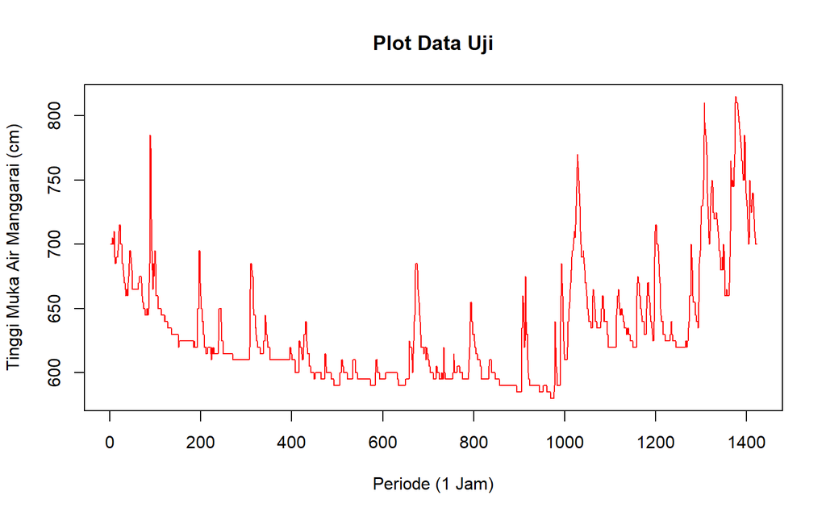

```r
tma.test<-TMA2[8755:10176]
test.ts<-ts(tma.test)
plot.ts(test.ts, lty=1, xlab="Periode (1 Jam)", ylab="Tinggi Muka Air Manggarai (cm)", main="Plot Data Uji", col="red")
```

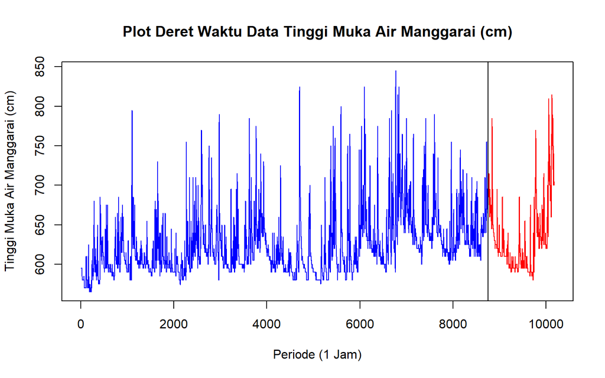

```r
ts.plot(TMA.ts, xlab = "Periode (1 Jam)", ylab ="Tinggi Muka Air Manggarai (cm)",
        main = "Plot Deret Waktu Data Tinggi Muka Air Manggarai (cm)", col="red")
lines(train.ts, col = "blue")
legend(8754,9,c("Data Training","Data Testing"),
       lty=8, col=c("blue","red"), cex=0.8)
abline(v=8754, col=c("black"), lty=1, lwd=1)
```

## Kestasioneran Dalam Ragam

### Plot Box-Cox

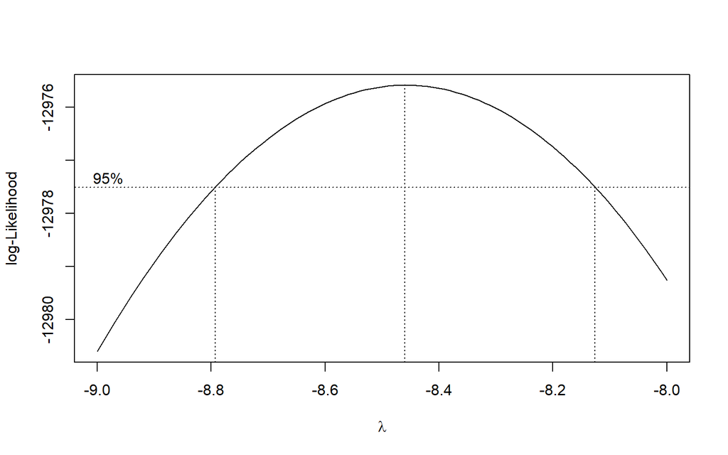

```r
index <- seq(1:8754)
bc = boxcox(train.ts~index, lambda = seq(-9,-8,by=0.01))
```

```r
#Nilai Rounded Lambda
lambda <- bc$x[which.max(bc$y)]
lambda
```

```
## [1] -8.46
```

```r
#SK
bc$x[bc$y > max(bc$y) - 1/2 * qchisq(.95,1)]
```

```
##  [1] -8.79 -8.78 -8.77 -8.76 -8.75 -8.74 -8.73 -8.72 -8.71 -8.70 -8.69 -8.68
## [13] -8.67 -8.66 -8.65 -8.64 -8.63 -8.62 -8.61 -8.60 -8.59 -8.58 -8.57 -8.56
## [25] -8.55 -8.54 -8.53 -8.52 -8.51 -8.50 -8.49 -8.48 -8.47 -8.46 -8.45 -8.44
## [37] -8.43 -8.42 -8.41 -8.40 -8.39 -8.38 -8.37 -8.36 -8.35 -8.34 -8.33 -8.32
## [49] -8.31 -8.30 -8.29 -8.28 -8.27 -8.26 -8.25 -8.24 -8.23 -8.22 -8.21 -8.20
## [61] -8.19 -8.18 -8.17 -8.16 -8.15 -8.14 -8.13
```

Plot Boxcox menunjukkan nilai *rounded value* ($\lambda$) optimum sebesar **-8.46** dan pada selang kepercayaan 95% nilai memiliki batas bawah **-8.79** dan batas atas **-8.13**. Selang tersebut tidak memuat nilai satu sehingga dapat dikatakan bahwa data yang digunakan tidak stasioner dalam ragam. Nilai lambda = -8.5 dipilih untuk melakukan transformasi,

#### Penanganan Ketidakstasioneran dalam ragam (Lambda = -8.5)

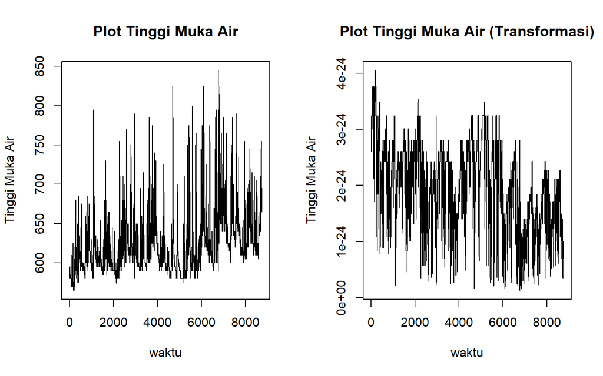

```r
# transformasi dengan nilai lambda = 0
data_boxcox = (train.ts)^(-8.5)

par(mfrow=c(1,2))
plot.ts(train.ts, lty=1, xlab="waktu", ylab="Tinggi Muka Air", main="Plot Tinggi Muka Air")
plot.ts(data_boxcox, lty=1, xlab="waktu", ylab="Tinggi Muka Air", main="Plot Tinggi Muka Air (Transformasi)")
```

#### Plot Box-Cox

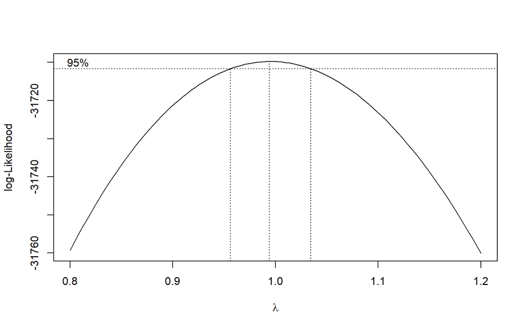

```r
index2 <- seq(1:8754)
bc2 = boxcox(data_boxcox~index, lambda = seq(0.8,1.2,by=0.01))
```

```r
#Nilai Rounded Lambda
lambda2 <- bc2$x[which.max(bc2$y)]
lambda2
```

```
## [1] 0.9939394
```

```r
#SK
bc2$x[bc2$y > max(bc2$y) - 1/2 * qchisq(.95,1)]
```

```
##  [1] 0.9575758 0.9616162 0.9656566 0.9696970 0.9737374 0.9777778 0.9818182
##  [8] 0.9858586 0.9898990 0.9939394 0.9979798 1.0020202 1.0060606 1.0101010
## [15] 1.0141414 1.0181818 1.0222222 1.0262626 1.0303030 1.0343434
```

Plot Boxcox memuat nilai satu sehingga dapat dikatakan bahwa data yang digunakan sudah stasioner dalam ragam.

## Uji Stasioneritas Data

### Plot ACF

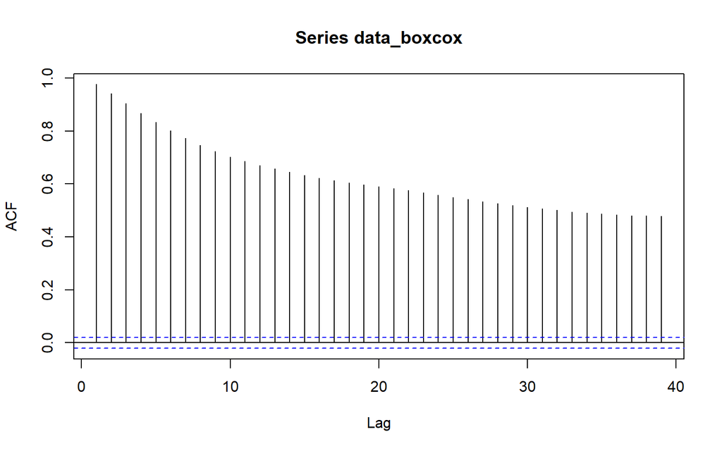

```r
acf(data_boxcox)
```

Berdasarkan plot ACF, terlihat bahwa plot ACF data menurun secara perlahan (*tails of slowly*). Hal ini juga menjadi indikasi bahwa data tidak stasioner dalam rataan

### Uji ADF

```r
tseries::adf.test(data_boxcox)
```

```
##
##  Augmented Dickey-Fuller Test
##
## data:  data_boxcox
## Dickey-Fuller = -9.5475, Lag order = 20, p-value = 0.01
## alternative hypothesis: stationary
```

$H_0$ : Data tidak stasioner dalam rataan

$H_1$ : Data stasioner dalam rataan

Berdasarkan uji ADF tersebut, didapat *p-value* sebesar 0.01 yang lebih kecil dari taraf nyata 5% sehingga tolak $H_0$ dan menandakan bahwa data stasioner dalam rataan. Hal ini tidak sesuai dengan hasil eksplorasi menggunakan plot time series dan plot ACF. Hal tersebut dapat disebabkan pada data yang terlalu besar untuk metode ARIMA, sehingga kami mencoba menyimpulkan bahwa data tersebut tidak stasioner

## Penanganan Ketidakstasioneran dalam rataan

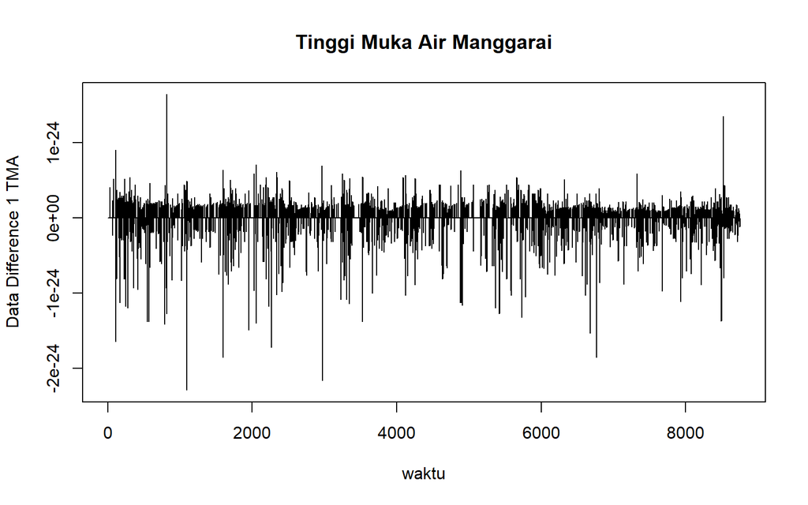

```r
train.dif<-diff(data_boxcox,differences = 1)
plot.ts(train.dif, lty=1, xlab="waktu", ylab="Data Difference 1 TMA", main="Tinggi Muka Air Manggarai")
```

### Plot ACF

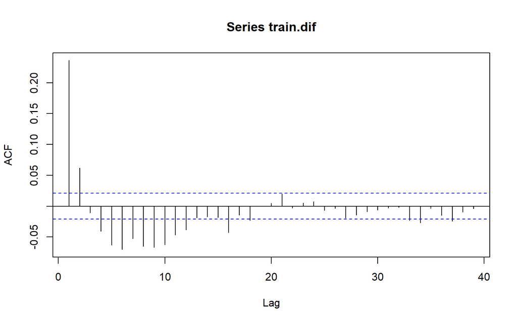

```r
acf(train.dif)
```

### Uji ADF

```r
tseries::adf.test(train.dif)
```

```
##
##  Augmented Dickey-Fuller Test
##
## data:  train.dif
## Dickey-Fuller = -25.74, Lag order = 20, p-value = 0.01
## alternative hypothesis: stationary
```

## Identifikasi Model

### Plot ACF

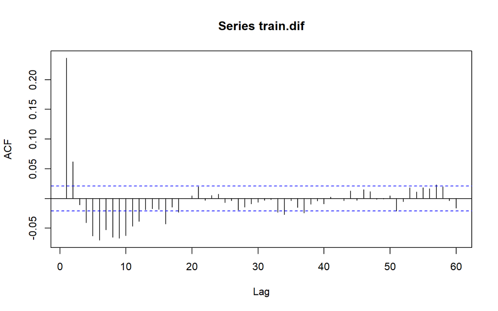

```r
acf(train.dif, 60)
```

Berdasarkan plot tersebut, terlihat bahwa plot ACF cenderung *cut off* pada lag 2. Jika PACF diasumsikan *tail off* maka model tentatif yang diperoleh adalah ARIMA(0,1,2)

### Plot PACF

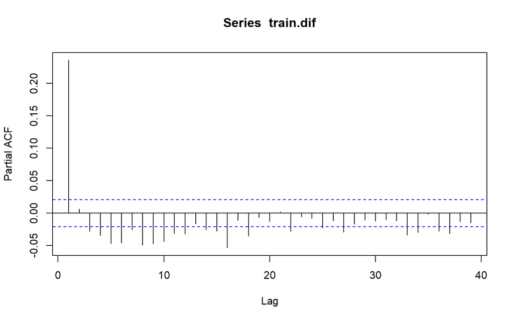

```r
pacf(train.dif)
```

Berdasarkan plot tersebut, terlihat bahwa plot PACF cenderung *cut off* pada lag 1. Jika ACF diasumsikan *tail off* maka model tentatif yang diperoleh adalah ARIMA(1,1,0)

### Plot EACF

```r
eacf(train.dif)
```

```
## AR/MA
##   0 1 2 3 4 5 6 7 8 9 10 11 12 13
## 0 x x o x x x x x x x x  x  o  o
## 1 x x o o o o o o o o o  o  o  o
## 2 x x o o o o o o o o o  o  o  o
## 3 x x x o o x o o o o o  o  o  o
## 4 x x x x o x o o o o o  o  o  o
## 5 x x x x x o x o o o o  o  o  o
## 6 x x x x o x x o o o o  o  o  o
## 7 x x x x o x x o o o o  o  o  o
```

Identifikasi model menggunakan plot EACF dilakukan dengan melihat ujung segitiga pada pola segitiga nol. Dalam hal ini model tentatif yang terbentuk adalah ARIMA(1,1,2), ARIMA(2,1,2), ARIMA(3,1,3), ARIMA(1,1,4)

## Pendugaan Parameter Model Tentatif

### ARIMA(0,1,2)

```r
model1.da=Arima(data_boxcox, order=c(0,1,2),method="ML")
summary(model1.da) #AIC=-974415.2
```

```
## Series: data_boxcox
## ARIMA(0,1,2)
##
## Coefficients:
##          ma1     ma2
##       0.2340  0.0674
## s.e.  0.0106  0.0107
##
## sigma^2 = 2.631e-50:  log likelihood = 487210.6
## AIC=-974415.2   AICc=-974415.2   BIC=-974394
##
## Training set error measures:
##                         ME         RMSE          MAE        MPE     MAPE
## Training set -1.685668e-28 1.621738e-25 7.527245e-26 -0.4502411 5.489738
##                  MASE        ACF1
## Training set 1.017033 0.000347514
```

```r
lmtest::coeftest(model1.da) #seluruh parameter signifikan
```

```
##
## z test of coefficients:
##
##     Estimate Std. Error z value  Pr(>|z|)
## ma1 0.233961   0.010645 21.9791 < 2.2e-16 ***
## ma2 0.067425   0.010721  6.2892 3.191e-10 ***
## ---
## Signif. codes:  0 '***' 0.001 '**' 0.01 '*' 0.05 '.' 0.1 ' ' 1
```

### ARIMA(1,1,0)

```r
model2.da=Arima(data_boxcox, order=c(1,1,0),method="ML")
summary(model2.da) #AIC=-974413.3
```

```
## Series: data_boxcox
## ARIMA(1,1,0)
##
## Coefficients:
##          ar1
##       0.2360
## s.e.  0.0104
##
## sigma^2 = 2.632e-50:  log likelihood = 487208.7
## AIC=-974413.3   AICc=-974413.3   BIC=-974399.2
##
## Training set error measures:
##                         ME       RMSE          MAE        MPE     MAPE     MASE
## Training set -1.678471e-28 1.6221e-25 7.490939e-26 -0.4403422 5.469234 1.012128
##                      ACF1
## Training set -0.001473161
```

```r
lmtest::coeftest(model2.da) # seluruh parameter signifikan
```

```
##
## z test of coefficients:
##
##     Estimate Std. Error z value  Pr(>|z|)
## ar1 0.235982   0.010384  22.726 < 2.2e-16 ***
## ---
## Signif. codes:  0 '***' 0.001 '**' 0.01 '*' 0.05 '.' 0.1 ' ' 1
```

### ARIMA(1,1,2)

```r
model3.da=Arima(data_boxcox, order=c(1,1,2),method="ML")
summary(model3.da) #AIC=-974413.1
```

```
## Series: data_boxcox
## ARIMA(1,1,2)
##
## Coefficients:
##          ar1     ma1     ma2
##       0.1172  0.1173  0.0417
## s.e.  0.1168  0.1168  0.0288
##
## sigma^2 = 2.631e-50:  log likelihood = 487210.5
## AIC=-974413.1   AICc=-974413.1   BIC=-974384.8
##
## Training set error measures:
##                         ME         RMSE          MAE        MPE     MAPE
## Training set -1.672624e-28 1.621753e-25 7.516181e-26 -0.4367418 5.478856
##                  MASE          ACF1
## Training set 1.015538 -2.927389e-05
```

```r
lmtest::coeftest(model3.da) #Tidak ada yang signifikan
```

```
##
## z test of coefficients:
##
##     Estimate Std. Error z value Pr(>|z|)
## ar1 0.117164   0.116808  1.0030   0.3158
## ma1 0.117335   0.116800  1.0046   0.3151
## ma2 0.041694   0.028800  1.4477   0.1477
```

### ARIMA(2,1,2)

```r
model4.da=Arima(data_boxcox, order=c(2,1,2),method="ML")
summary(model4.da) #AIC=-974411.9
```

```
## Series: data_boxcox
## ARIMA(2,1,2)
##
## Coefficients:
```

```
##          ar1      ar2     ma1     ma2
##       0.1062  -0.0338  0.1275  0.0771
## s.e.     NaN      NaN     NaN  0.0261
##
## sigma^2 = 2.631e-50:  log likelihood = 487211
## AIC=-974411.9   AICc=-974411.9   BIC=-974376.5
##
## Training set error measures:
##                         ME         RMSE          MAE        MPE    MAPE
## Training set -1.688812e-28 1.621677e-25 7.526983e-26 -0.4537967 5.49041
##                  MASE        ACF1
## Training set 1.016998 0.000520666
```

```r
lmtest::coeftest(model4.da) #NaNs produced
```

```
##
## z test of coefficients:
##
##      Estimate Std. Error z value Pr(>|z|)
## ar1  0.106243        NaN     NaN      NaN
## ar2 -0.033844        NaN     NaN      NaN
## ma1  0.127457        NaN     NaN      NaN
## ma2  0.077084   0.026138  2.9491 0.003187 **
## ---
## Signif. codes:  0 '***' 0.001 '**' 0.01 '*' 0.05 '.' 0.1 ' ' 1
```

### ARIMA(3,1,3)

```r
model5.da=Arima(data_boxcox, order=c(3,1,3),method="ML")
summary(model5.da) #AIC=-974652.1
```

```
## Series: data_boxcox
## ARIMA(3,1,3)
##
## Coefficients:
##          ar1     ar2      ar3     ma1      ma2     ma3
##       0.4876  0.8085  -0.3908  -0.280  -0.8768  0.1785
## s.e.  0.1226  0.1610   0.0602   0.124   0.1381  0.0448
##
## sigma^2 = 2.559e-50:  log likelihood = 487333.1
## AIC=-974652.1   AICc=-974652.1   BIC=-974602.6
##
## Training set error measures:
##                         ME         RMSE          MAE      MPE     MAPE     MASE
## Training set -8.712923e-28 1.599138e-25 7.988928e-26 -1.36575 5.768018 1.079413
##                       ACF1
## Training set -0.0005427836
```

```r
lmtest::coeftest(model5.da) #Semua parameter signifikan
```

```
##
## z test of coefficients:
##
##      Estimate Std. Error z value  Pr(>|z|)
## ar1  0.487592   0.122582  3.9777 6.959e-05 ***
## ar2  0.808490   0.160998  5.0217 5.121e-07 ***
## ar3 -0.390842   0.060240 -6.4881 8.693e-11 ***
## ma1 -0.279963   0.124047 -2.2569   0.02401 *
## ma2 -0.876829   0.138079 -6.3502 2.150e-10 ***
## ma3  0.178540   0.044779  3.9872 6.687e-05 ***
## ---
## Signif. codes:  0 '***' 0.001 '**' 0.01 '*' 0.05 '.' 0.1 ' ' 1
```

### ARIMA(1,1,4)

```r
model6.da=Arima(data_boxcox, order=c(1,1,4),method="ML")
summary(model6.da) #AIC=-974646.8
```

```
## Series: data_boxcox
## ARIMA(1,1,4)
##
## Coefficients:
##          ar1      ma1      ma2      ma3      ma4
##       0.9191  -0.7132  -0.1574  -0.0688  -0.0443
## s.e.  0.0078   0.0130   0.0130   0.0132   0.0117
##
## sigma^2 = 2.561e-50:  log likelihood = 487329.4
## AIC=-974646.8   AICc=-974646.8   BIC=-974604.3
##
## Training set error measures:
##                         ME         RMSE          MAE       MPE     MAPE
## Training set -9.765877e-28 1.599802e-25 7.988929e-26 -1.399307 5.790963
##                  MASE         ACF1
## Training set 1.079413 0.0009475957
```

```r
lmtest::coeftest(model6.da) #Seluruh parameter signifikan
```

```
##
## z test of coefficients:
##
##       Estimate Std. Error  z value  Pr(>|z|)
## ar1  0.9191456  0.0078256 117.4543 < 2.2e-16 ***
## ma1 -0.7131530  0.0129972 -54.8699 < 2.2e-16 ***
## ma2 -0.1573778  0.0130178 -12.0894 < 2.2e-16 ***
## ma3 -0.0687527  0.0131757  -5.2182 1.807e-07 ***
## ma4 -0.0443360  0.0116734  -3.7980 0.0001458 ***
## ---
## Signif. codes:  0 '***' 0.001 '**' 0.01 '*' 0.05 '.' 0.1 ' ' 1
```

```r
library(knitr)
kable(
  cbind(c("ARIMA (0,1,2)","ARIMA (1,1,0)","ARIMA (1,1,2)","ARIMA (2,1,2)","ARIMA (3,1,3)","ARIMA (1,1,4)"),
        c(model1.da$aic,model2.da$aic,model3.da$aic,model4.da$aic,model5.da$aic,model6.da$aic)),
  col.names=c("Model","AIC")
)
```

| Model | AIC |
| --- | --- |
| ARIMA (0,1,2) | -974415.246422957 |
| ARIMA (1,1,0) | -974413.340728512 |
| ARIMA (1,1,2) | -974413.081811254 |
| ARIMA (2,1,2) | -974411.909664685 |
| ARIMA (3,1,3) | -974652.141274288 |
| ARIMA (1,1,4) | -974646.817640355 |

Berdasarkan pendugaan parameter di atas, model ARIMA(3,1,3) dengan seluruh parameternya signifikan pada taraf 5% serta AIC paling kecil. Oleh karena itu model ARIMA(3,1,3) dipilih untuk proses berikutnya

## Analisis Sisaan

Model terbaik hasil identifikasi kemudian dicek asumsi sisaannya. Sisaan model ARIMA harus memenuhi asumsi normalitas, kebebasan sisaan, dan kehomogenan ragam. Diagnostik model dilakukan secara eksplorasi dan uji formal.

### Eksplorasi Sisaan

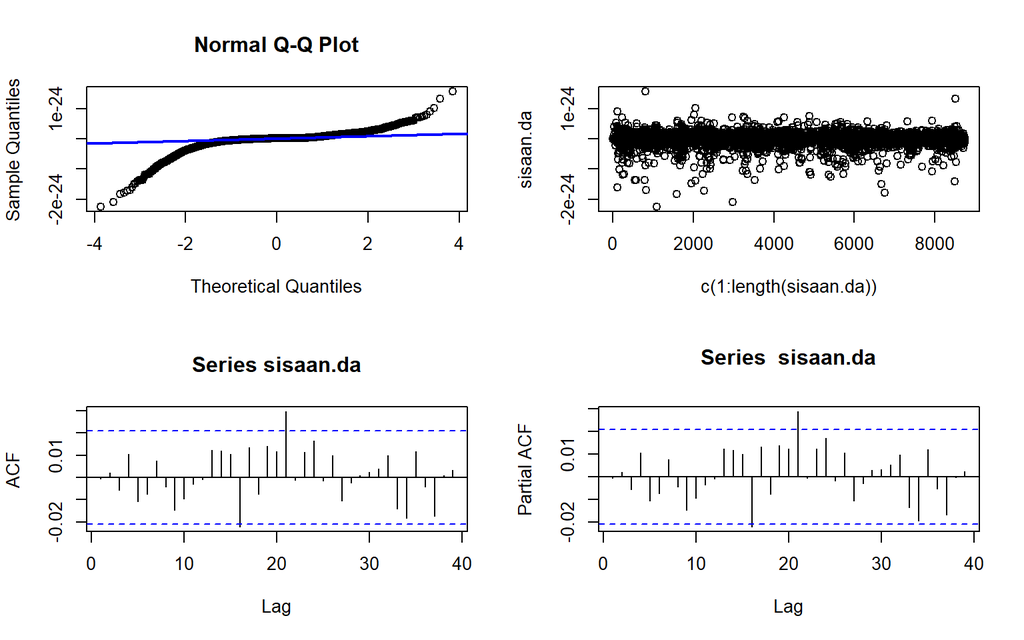

```r
#Eksplorasi
sisaan.da <- model5.da$residuals
par(mfrow=c(2,2))
qqnorm(sisaan.da)
qqline(sisaan.da, col = "blue", lwd = 2)
plot(c(1:length(sisaan.da)),sisaan.da)
acf(sisaan.da)
pacf(sisaan.da)
```

```r
par(mfrow = c(1,1))
```

Berdasarkan plot kuantil-kuantil normal, secara eksplorasi ditunjukkan sisaan tidak menyebar normal ditandai dengan titik titik yang cenderung tidak mengikuti garis $45^{\circ}$. Kemudian dapat dilihat juga lebar pita sisaan yang cenderung tidak sama menandakan bahwa sisaan memiliki ragam yang tidak homogen. Plot ACF dan PACF sisaan ARIMA(3,1,3) juga ada yang signifikan pada 20 lag awal yang menandakan tidak saling bebas. Kondisi ini akan diuji lebih lanjut dengan uji formal.

### Uji Formal

```r
#1) Sisaan Menyebar Normal
tseries::jarque.bera.test(sisaan.da);  #tak tolak H0 > sisaan menyebar normal
```

```
##
##  Jarque Bera Test
##
## data:  sisaan.da
## X-squared = 388528, df = 2, p-value < 2.2e-16
```

```r
nortest::ad.test(sisaan.da)
```

```
##
##  Anderson-Darling normality test
##
## data:  sisaan.da
## A = 780.31, p-value < 2.2e-16
```

Selain dengan eksplorasi, asumsi tersebut dapat diuji menggunakan uji formal. Pada tahapan ini uji formal yang digunakan untuk normalitas adalah uji Jarque Bera . Hipotesis pada uji Jarque Bera adalah sebagai berikut.

$H_0$ : Sisaan menyebar normal

$H_1$ : Sisaan tidak menyebar normal

Berdasarkan uji Jarque-Bera tersebut, didapat *p-value* sebesar 2.2e-16 yang kurang dari taraf nyata 5% sehingga tolak $H_0$ dan menandakan bahwa sisaan tidak menyebar normal. Hal ini sesuai dengan hasil eksplorasi menggunakan plot kuantil-kuantil normal.

```r
#2) Sisaan saling bebas/tidak ada autokorelasi
Box.test(sisaan.da, type = "Ljung")  #tak tolak H0 > sisaan saling bebas
```

```
##
##  Box-Ljung test
##
## data:  sisaan.da
## X-squared = 0.0025799, df = 1, p-value = 0.9595
```

Selanjutnya akan dilakukan uji formal untuk kebebasan sisaan menggunakan uji Ljung-Box. Hipotesis yang digunakan adalah sebagai berikut.

$H_0$ : Sisaan saling bebas

$H_1$ : Sisaan tidak tidak saling bebas

```r
#3) Sisaan homogen
Box.test((sisaan.da)^2, type = "Ljung")  #tak tolak H0 > sisaan homogen
```

```
##
##  Box-Ljung test
##
## data:  (sisaan.da)^2
## X-squared = 109.42, df = 1, p-value < 2.2e-16
```

Hipotesis yang digunakan untuk uji kehomogenan ragam adalah sebagai berikut.

$H_0$ : Ragam sisaan homogen

$H_1$ : Ragam sisaan tidak homogen

Berdasarkan uji Ljung-Box terhadap sisaan kuadrat tersebut, didapat *p-value* sebesar 2.2e-16 yang lebih kecil dari taraf nyata 5% sehingga tolak $H_0$ dan menandakan bahwa ragam sisaan tidak homogen.

```r
#4) Nilai tengah sisaan sama dengan nol
t.test(sisaan.da, mu = 0, conf.level = 0.95)  #tak tolak h0 > nilai tengah sisaan sama dengan 0
```

```
##
##  One Sample t-test
##
## data:  sisaan.da
## t = -0.50976, df = 8753, p-value = 0.6102
## alternative hypothesis: true mean is not equal to 0
## 95 percent confidence interval:
##  -4.221790e-27  2.479205e-27
## sample estimates:
##     mean of x
## -8.712923e-28
```

Terakhir, dengan uji-t, akan dicek apakah nilai tengah sisaan sama dengan nol. Hipotesis yang diujikan sebagai berikut.

$H_0$ : nilai tengah sisaan sama dengan 0

$H_1$ : nilai tengah sisaan tidak sama dengan 0

Berdasarkan uji-ttersebut, didapat *p-value* sebesar 0.6102 yang lebih besar dari taraf nyata 5% sehingga tak tolak $H_0$ dan menandakan bahwa nilai tengah sisaan sama dengan nol. Hal ini sama dengan hasil eksplorasi.

## Overfitting

Tahapan selanjutnya adalah *overfitting* dilakukan dengan menaikkan orde AR(p) dan MA(q) dari model ARIMA(3,1,3) untuk melihat apakah terdapat model lain yang lebih baik dari model saat ini. Kandidat model *overfitting* adalah ARIMA(3,1,4) dan ARIMA(4,1,3).

### Model ARIMA(3,1,4)

```r
model.overfit1=Arima(data_boxcox, order=c(3,1,4),method="ML")
summary(model.overfit1) #-974650.8
```

```
## Series: data_boxcox
## ARIMA(3,1,4)
##
## Coefficients:
##          ar1     ar2      ar3      ma1      ma2     ma3      ma4
##       0.4595  0.8417  -0.3975  -0.2523  -0.9029  0.1795  -0.0023
## s.e.  0.0948  0.0776   0.0759   0.0955   0.0701  0.0769   0.0239
##
## sigma^2 = 2.559e-50:  log likelihood = 487333.4
## AIC=-974650.8   AICc=-974650.8   BIC=-974594.2
##
## Training set error measures:
##                        ME         RMSE          MAE       MPE    MAPE     MASE
## Training set -8.76642e-28 1.599077e-25 7.988116e-26 -1.365437 5.76739 1.079303
##                      ACF1
## Training set 1.657915e-05
```

```r
lmtest::coeftest(model.overfit1) # Ma4 tidak signifikan
```

```
##
## z test of coefficients:
##
##       Estimate Std. Error  z value  Pr(>|z|)
## ar1  0.4594955  0.0947668   4.8487 1.243e-06 ***
## ar2  0.8417263  0.0775677  10.8515 < 2.2e-16 ***
## ar3 -0.3975143  0.0759110  -5.2366 1.636e-07 ***
## ma1 -0.2523495  0.0955192  -2.6419  0.008245 **
## ma2 -0.9029438  0.0700711 -12.8861 < 2.2e-16 ***
## ma3  0.1795351  0.0769084   2.3344  0.019575 *
## ma4 -0.0022885  0.0238855  -0.0958  0.923669
## ---
## Signif. codes:  0 '***' 0.001 '**' 0.01 '*' 0.05 '.' 0.1 ' ' 1
```

### Model ARIMA(4,1,3)

```r
model.overfit2=Arima(data_boxcox, order=c(4,1,3),method="ML")
summary(model.overfit2) #-969992.3
```

```
## Series: data_boxcox
## ARIMA(4,1,3)
##
## Coefficients:
```

```
##          ar1     ar2     ar3      ar4     ma1      ma2      ma3
##       0.1515  0.5934  0.2538  -0.1402  0.0587  -0.5937  -0.4361
## s.e.     NaN  0.2632  0.0388      NaN     NaN   0.2518      NaN
##
## sigma^2 = 2.562e-50:  log likelihood = 487329.2
## AIC=-974642.3   AICc=-974642.3   BIC=-974585.7
##
## Training set error measures:
##                         ME        RMSE          MAE       MPE     MAPE     MASE
## Training set -9.670832e-28 1.59985e-25 7.998806e-26 -1.399547 5.795416 1.080748
##                      ACF1
## Training set -0.003043774
```

```r
lmtest::coeftest(model.overfit2) #NaNs produced
```

```
##
## z test of coefficients:
##
##      Estimate Std. Error z value  Pr(>|z|)
## ar1  0.151463        NaN     NaN       NaN
## ar2  0.593437   0.263223  2.2545   0.02416 *
## ar3  0.253758   0.038831  6.5349 6.366e-11 ***
## ar4 -0.140166        NaN     NaN       NaN
## ma1  0.058746        NaN     NaN       NaN
## ma2 -0.593678   0.251778 -2.3579   0.01838 *
## ma3 -0.436093        NaN     NaN       NaN
## ---
## Signif. codes:  0 '***' 0.001 '**' 0.01 '*' 0.05 '.' 0.1 ' ' 1
```

Berdasarkan pendugaan parameter model over vitting di atas, tidak seluruh parameter signifikan. Sehingga model terbaik yang dipilih adalah model ARIMA (3,1,3)

```r
library(knitr)
kable(
  cbind(c("ARIMA (0,1,2)","ARIMA (1,1,0)","ARIMA (1,1,2)","ARIMA (2,1,2)","ARIMA (3,1,3)","ARIMA (3,1,4) Overfit","ARIMA (4,1,3) Overfit"),
        c(model1.da$aic,model2.da$aic,model3.da$aic,model4.da$aic,model5.da$aic,model.overfit1$aic,model.overfit2$aic)),
  col.names=c("Model","AIC")
)
```

| Model | AIC |
| --- | --- |
| ARIMA (0,1,2) | -974415.246422957 |
| ARIMA (1,1,0) | -974413.340728512 |
| ARIMA (1,1,2) | -974413.081811254 |
| ARIMA (2,1,2) | -974411.909664685 |
| ARIMA (3,1,3) | -974652.141274288 |
| ARIMA (3,1,4) Overfit | -974650.810458724 |
| ARIMA (4,1,3) Overfit | -974642.294963427 |

## Performa Model

Peramalan dilakukan menggunakan fungsi `forecast()`. Contoh peramalan berikut ini dilakukan untuk 1422 periode (jam) ke depan.

```r
#---FORECAST---#
ramalan.da <- forecast::forecast(model5.da, h = 1422)
ramalan.da
```

```
##       Point Forecast         Lo 80        Hi 80         Lo 95        Hi 95
##  8755   6.997456e-25  4.947257e-25 9.047654e-25  3.861948e-25 1.013296e-24
##  8756   7.164260e-25  3.949716e-25 1.037880e-24  2.248040e-25 1.208048e-24
##  8757   7.385826e-25  3.286824e-25 1.148483e-24  1.116943e-25 1.365471e-24
##  8758   7.617339e-25  2.823841e-25 1.241084e-24  2.863168e-26 1.494836e-24
##  8759   7.844163e-25  2.507860e-25 1.318047e-24 -3.170086e-26 1.600533e-24
##  8760   8.055339e-25  2.282148e-25 1.382853e-24 -7.739944e-26 1.688467e-24
##  8761   8.251206e-25  2.127080e-25 1.437533e-24 -1.114837e-25 1.761725e-24
##  8762   8.428792e-25  2.015040e-25 1.484254e-24 -1.380195e-25 1.823778e-24
##  8763   8.591201e-25  1.939109e-25 1.524329e-24 -1.582297e-25 1.876470e-24
##  8764   8.737414e-25  1.884445e-25 1.559038e-24 -1.743298e-25 1.921813e-24
##  8765   8.870605e-25  1.848998e-25 1.589221e-24 -1.868017e-25 1.960923e-24
##  8766   8.990282e-25  1.824070e-25 1.615649e-24 -1.969493e-25 1.995006e-24
##  8767   9.099174e-25  1.809501e-25 1.638885e-24 -2.049419e-25 2.024777e-24
##  8768   9.196970e-25  1.799855e-25 1.659409e-24 -2.115941e-25 2.050988e-24
```

[output cut: 1408 more lines]

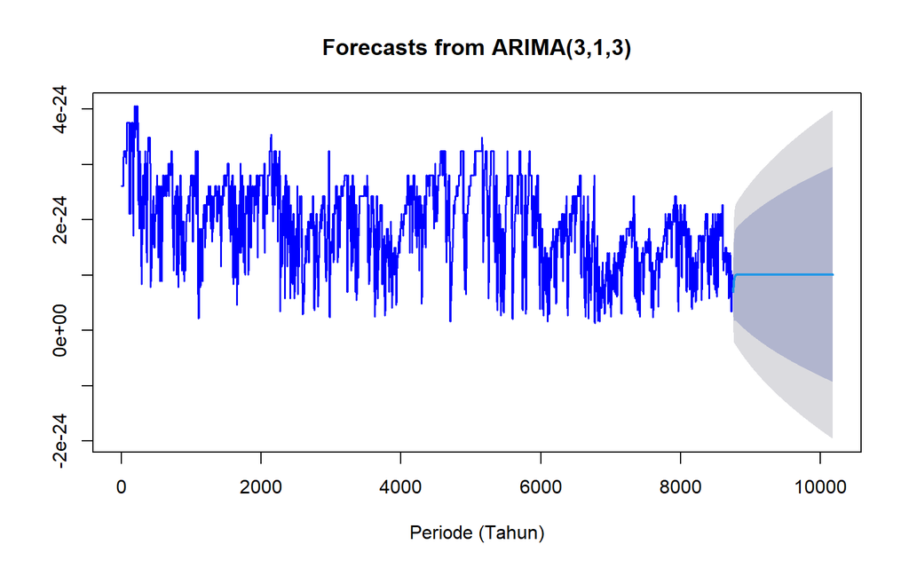

```r
data.ramalan.da <- ramalan.da$mean
plot(ramalan.da, xlab="Periode (Tahun)", col = "blue", lwd=1.5)
```

Berdasarkan hasil plot ramalan di atas, dapat dilihat bahwa ramalan ARIMA(3,1,3) cenderung stabil hingga akhir periode. Selanjutnya, dapat dicari nilai akurasi antara hasil ramalan dengan data uji sebagai berikut.

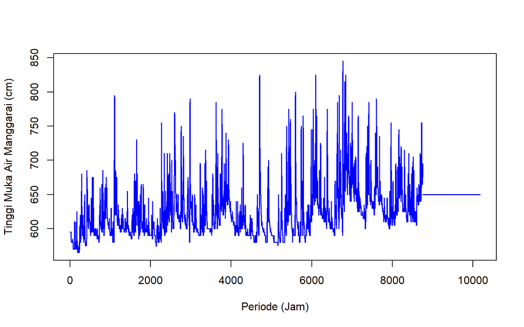

```r
pt_1 <- (data_boxcox[1422])^(-1/8.5) #nilai akhir data latih
hasil.forc.Diff <- data.ramalan.da
hasil <- diffinv(hasil.forc.Diff, differences = 1) + pt_1

#has.1 sama hasilnta dengan: cumsum(c(pt_1,hasil.forc.Diff))
ts.plot(train.ts,hasil, ylab="Tinggi Muka Air Manggarai (cm)",
        xlab = "Periode (Jam)",
        col = "blue", lwd=1.5)
```

```r
perbandingan.da<-matrix(data=c(head(test.ts, n=1422), hasil[-1]),
                     nrow = 1422, ncol = 2)
colnames(perbandingan.da)<-c("Aktual","Hasil Forecast")
perbandingan.da
```

```
##         Aktual Hasil Forecast
##    [1,]    700            650
##    [2,]    700            650
##    [3,]    700            650
##    [4,]    700            650
##    [5,]    700            650
##    [6,]    705            650
##    [7,]    700            650
##    [8,]    700            650
##    [9,]    710            650
##   [10,]    700            650
##   [11,]    690            650
##   [12,]    685            650
##   [13,]    685            650
##   [14,]    690            650
```

[output cut: 1408 more lines]

```r
accuracy(ts(hasil[-1]), head(test.ts, n = 1422))
```

```
##                ME     RMSE      MAE       MPE     MAPE      ACF1 Theil's U
## Test set -16.3045 47.95593 40.58017 -3.047809 6.380801 0.9846154  6.491141
```